# Regresi Logistik

## Persiapan data

```r
germancredit <- read.csv(file="https://github.com/alfanugraha/tsa-handson/raw/master/german_credit.csv",
                header = T,
                sep = ",")
str(germancredit)
```

```
'data.frame':   1000 obs. of  21 variables:
 $ creditability          : int  1 1 1 1 1 1 1 1 1 1 ...
 $ account_balance        : int  1 1 2 1 1 1 1 1 4 2 ...
 $ duration               : int  18 9 12 12 12 10 8 6 18 24 ...
 $ payment_status         : int  4 4 2 4 4 4 4 4 4 2 ...
 $ purpose                : int  2 0 9 0 0 0 0 0 3 3 ...
 $ credit_amount          : int  1049 2799 841 2122 2171 2241 3398 1361 1098 3758 ...
 $ stocks                 : int  1 1 2 1 1 1 1 1 1 3 ...
 $ length_employment      : int  2 3 4 3 3 2 4 2 1 1 ...
 $ instalment_percent     : int  4 2 2 3 4 1 1 2 4 1 ...
 $ sex_marital_status     : int  2 3 2 3 3 3 3 3 2 2 ...
 $ guarantors             : int  1 1 1 1 1 1 1 1 1 1 ...
 $ duration_currentaddress: int  4 2 4 2 4 3 4 4 4 4 ...
 $ most_available_asset   : int  2 1 1 1 2 1 1 1 3 4 ...
 $ age                    : int  21 36 23 39 38 48 39 40 65 23 ...
 $ concurrent_credits     : int  3 3 3 3 1 3 3 3 3 3 ...
 $ type_apartment         : int  1 1 1 1 2 1 2 2 2 1 ...
 $ no_credits             : int  1 2 1 2 2 2 2 1 2 1 ...
 $ cccupation             : int  3 3 2 2 2 2 2 2 1 1 ...
 $ no_dependents          : int  1 2 1 2 1 2 1 2 1 1 ...
 $ telephone              : int  1 1 1 1 1 1 1 1 1 1 ...
 $ foreign_worker         : int  1 1 1 2 2 2 2 2 1 1 ...
```

Tentang gugus data German Credit.

[output not shown]

[output cut: 990 more lines]

```r
skimr::skim(germancredit)
```

[output not shown]

[output not shown]

|  | skim_variable | n_missing | complete_rate | mean | sd | p0 | p25 | p50 | p75 | p100 | hist |
| --- | --- | --- | --- | --- | --- | --- | --- | --- | --- | --- | --- |
| 1 | duration | 0 | 1 | 20.903 | 12.0588145 | 4 | 12.0 | 18.0 | 24.00 | 72 | ▇▇▂▁▁ |
| 2 | credit_amount | 0 | 1 | 3271.248 | 2822.7517599 | 250 | 1365.5 | 2319.5 | 3972.25 | 18424 | ▇▂▁▁▁ |
| 3 | instalment_percent | 0 | 1 | 2.973 | 1.1187147 | 1 | 2.0 | 3.0 | 4.00 | 4 | ▂▃▁▂▇ |
| 4 | guarantors | 0 | 1 | 1.145 | 0.4777062 | 1 | 1.0 | 1.0 | 1.00 | 3 | ▇▁▁▁▁ |
| 5 | duration_currentaddress | 0 | 1 | 2.845 | 1.1037179 | 1 | 2.0 | 3.0 | 4.00 | 4 | ▂▆▁▃▇ |
| 6 | most_available_asset | 0 | 1 | 2.358 | 1.0502090 | 1 | 1.0 | 2.0 | 3.00 | 4 | ▇▆▁▇▃ |
| 7 | age | 0 | 1 | 35.542 | 11.3526701 | 19 | 27.0 | 33.0 | 42.00 | 75 | ▇▆▃▁▁ |
| 8 | concurrent_credits | 0 | 1 | 2.675 | 0.7056011 | 1 | 3.0 | 3.0 | 3.00 | 3 | ▂▁▁▁▇ |
| 9 | type_apartment | 0 | 1 | 1.928 | 0.5301859 | 1 | 2.0 | 2.0 | 2.00 | 3 | ▂▁▇▁▁ |
| 10 | cccupation | 0 | 1 | 2.904 | 0.6536140 | 1 | 3.0 | 3.0 | 3.00 | 4 | ▁▂▁▇▂ |

[output cut: 2 more lines]

Konversi beberapa data numerik sebagai data kategorik

```r
germancredit$creditability <- as.factor(germancredit$creditability)
germancredit$account_balance <- as.factor(germancredit$account_balance)
germancredit$payment_status <- as.factor(germancredit$payment_status)
germancredit$stocks <- as.factor(germancredit$stocks)
germancredit$length_employment <- as.factor(germancredit$length_employment)
germancredit$sex_marital_status <- as.factor(germancredit$sex_marital_status)
germancredit$no_credits <- as.factor(germancredit$no_credits)
germancredit$foreign_worker <- as.factor(germancredit$foreign_worker)
germancredit$purpose <- as.factor(germancredit$purpose)
```

### Statistik deskriptif

```r
summary(germancredit)
```

```
 creditability account_balance    duration    payment_status    purpose    credit_amount   stocks
 0:300         1:274           Min.   : 4.0   0: 40          3      :280   Min.   :  250   1:603
 1:700         2:269           1st Qu.:12.0   1: 49          0      :234   1st Qu.: 1366   2:103
               3: 63           Median :18.0   2:530          2      :181   Median : 2320   3: 63
               4:394           Mean   :20.9   3: 88          1      :103   Mean   : 3271   4: 48
                               3rd Qu.:24.0   4:293          9      : 97   3rd Qu.: 3972   5:183
                               Max.   :72.0                  6      : 50   Max.   :18424
                                                             (Other): 55
 length_employment instalment_percent sex_marital_status   guarantors    duration_currentaddress
 1: 62             Min.   :1.000      1: 50              Min.   :1.000   Min.   :1.000
 2:172             1st Qu.:2.000      2:310              1st Qu.:1.000   1st Qu.:2.000
 3:339             Median :3.000      3:548              Median :1.000   Median :3.000
 4:174             Mean   :2.973      4: 92              Mean   :1.145   Mean   :2.845
 5:253             3rd Qu.:4.000                         3rd Qu.:1.000   3rd Qu.:4.000
                   Max.   :4.000                         Max.   :3.000   Max.   :4.000

 most_available_asset      age        concurrent_credits type_apartment  no_credits   cccupation
 Min.   :1.000        Min.   :19.00   Min.   :1.000      Min.   :1.000   1:633      Min.   :1.000
 1st Qu.:1.000        1st Qu.:27.00   1st Qu.:3.000      1st Qu.:2.000   2:333      1st Qu.:3.000
 Median :2.000        Median :33.00   Median :3.000      Median :2.000   3: 28      Median :3.000
 Mean   :2.358        Mean   :35.54   Mean   :2.675      Mean   :1.928   4:  6      Mean   :2.904
 3rd Qu.:3.000        3rd Qu.:42.00   3rd Qu.:3.000      3rd Qu.:2.000              3rd Qu.:3.000
 Max.   :4.000        Max.   :75.00   Max.   :3.000      Max.   :3.000              Max.   :4.000

 no_dependents     telephone     foreign_worker
 Min.   :1.000   Min.   :1.000   1:963
 1st Qu.:1.000   1st Qu.:1.000   2: 37
 Median :1.000   Median :1.000
 Mean   :1.155   Mean   :1.404
 3rd Qu.:1.000   3rd Qu.:2.000
 Max.   :2.000   Max.   :2.000
```

```r
prop.table(table(germancredit$creditability))
```

```
  0   1
0.3 0.7
```

Data tersebut memiliki 30% pemohon kredit dengan kategori buruk, 70% sisanya dengan kategori baik

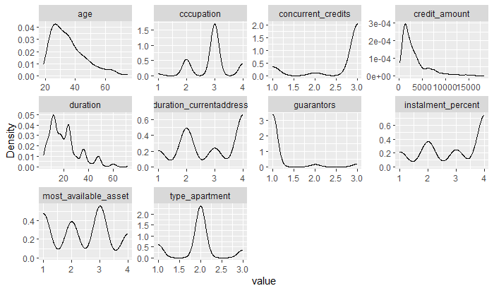

```r
library(DataExplorer)
plot_density(germancredit)
```

[figure not shown]

[figure not shown]

### Boxplot peubah numerik

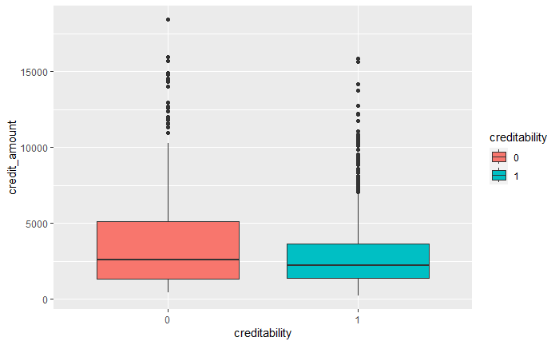

```r
ggplot(germancredit, aes(x=creditability, y=credit_amount, fill=creditability)) +
  geom_boxplot()
```

### Grafik batang peubah kategorik

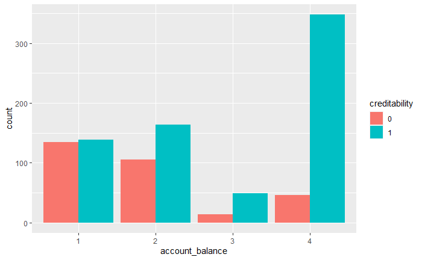

```r
ggplot(germancredit, aes(account_balance, after_stat(count))) +
  geom_bar(aes(fill=creditability), position = "dodge")
```

### Partisi/splitting data

```r
# generate indeks data
indeks <- sample(1:nrow(germancredit), size = 0.7 * nrow(germancredit))

# partisi 70%
train70 <- germancredit[indeks, ] # berisi 70%
test30 <- germancredit[-indeks, ] # berisi 30%
```

## Regresi Logistik Biner

Sebagai pengantar pada regresi klasik, sisaan $\epsilon$ diasumsikan menyebar normal, yang berarti Y juga menyebar normal. Namun pada kasus tertentu Y dapat berupa kategorik, misalnya kasus biner.

Makna garis lurus jika digunakan pada kasus biner bentuk pola prediksi Y menjadi jauh lebih besar dari 1 (positif), atau bisa juga menjadi sangat negatif sehingga dianggap tidak sesuai dengan hasil sebenarnya.

Odds adalah rasio peluang sukses dibagi peluang gagal, dimana peluang sukses > peluang gagal. Nilai odd disebut juga nilai logit

Logit adalah nilai log dari odds yang sama dengan $\alpha + \beta X$.

Pada regresi linear jika nilai $X$ naik satu satuan maka $\beta$ meningkat satu satuan. Pada logit jika nilai $X$ naik satu satuan maka odds meningkat $e^{\beta}$ satuan. Merasiokan odd atau odds ratio sama saja dengan nilai $e^{\beta}$.

Jika odd ratio bernilai 2, maknanya bahwa odds pada saat $X=x+1$ sama dengan 2 kali dari odds pada saat $X=x$. Kesimpulannya adalah peluang sukses terjadi 2 kali dari kejadian peluang gagal.

### Pemodelan

```r
reglog <- glm(creditability ~ ., family = binomial, data=train70)
summary(reglog)
```

```r
reglog2 <- glm(creditability ~ account_balance + credit_amount + instalment_percent + stocks + purpose,
              family = binomial,
              data=train70)
summary(reglog2)
```

### Seleksi fitur dengan stepwise

```r
reglog_step <- step(reglog)
```

```r
summary(reglog_step)
```

### Final model

```r
reglog_final <- glm(formula = creditability ~ account_balance + payment_status +
    purpose + credit_amount + stocks + length_employment + instalment_percent +
    most_available_asset + concurrent_credits + type_apartment + telephone + foreign_worker,
    family = binomial, data = train70)
summary(reglog_final)
```

### Kinerja Model

Validasi model pada regresi logistik untuk peubah Y sudah dipastikan bahwa:

- tidak menyebar normal
- varian atau ragam peubah Y berubah dan tidak konstan
- masalah multikolinearitas terkait pendugaan parameter, jika menduga dengan Least Square maka multikolinearitas tetap diperhatikan. Regresi gulud (ridge) dapat digunakan untuk kasus regresi klasik terhadap asumsi ini, tetapi tidak ada penanganan hal tersebut di regresi logistik.

Regresi klasik menggunakan analisis ragam (ANOVA) untuk melihat kinerja model. Secara prinsip, Y pada regresi logistik hanya bersifat biner, ukuran yang dapat digunakan untuk menilai kebaikan model adalah dengan menggunakan uji likelihood ratio test atau chi-square. Cara lain dalam menilai kebaikan regresi logistik bisa dilihat dari kemampuan prediksinya dimana kemampuan memprediksi untuk kasus klasifikasi yang cocok dapat menggunakan tabel klasifikasi atau *confusion matrix*

#### Confusion matrix

```r
# fitted.values
fit70 <- fitted.values(reglog_final)
pred_fit70 <- ifelse(fit70 >= 0.5, 1, 0)
conftab <- table(train70$creditability, pred_fit70, dnn = c("Aktual", "Prediksi"))
conftab
```

[output not shown]

```r
cat("Akurasi\t=", sum(diag(conftab)/sum(conftab)), "\n")
```

Cara lain dengan perhitungan manual untuk melihat performa model menggunakan data latih

```r
# predict
pred_reglog70 <- predict(reglog_final, train70, type="response")
y_pred <- ifelse(pred_reglog70 >= 0.5, 1, 0)
y_act <- train70$creditability

tbl_klas_reglog <- table(y_act, y_pred)
tbl_klas_reglog
```

[output not shown]

```r
akurasi <- (tbl_klas_reglog[1,1] + tbl_klas_reglog[2,2]) / sum(tbl_klas_reglog) * 100
sensitivitas <- tbl_klas_reglog[2,2] / sum(tbl_klas_reglog[2,]) * 100
spesifisitas <- tbl_klas_reglog[1,1] / sum(tbl_klas_reglog[1,]) * 100
fprate <- tbl_klas_reglog[2,1] / (tbl_klas_reglog[2,1] + tbl_klas_reglog[1,1]) * 100
AUC <- (100 + sensitivitas - fprate) / 2

performa <- data.frame(akurasi, sensitivitas, spesifisitas, AUC)
performa
```

### Prediksi Model

#### Kurva ROC

Menguji model dengan data uji

```r
# predict.glm
pred_reglog_fin <- predict.glm(reglog_final, test30)
pred_rocr <- prediction(pred_reglog_fin, test30$creditability)
perf_rocr <- performance(pred_rocr, "tpr", "fpr")
plot(perf_rocr)
```

[output not shown]

## Regresi Logistik Multinomial

Data yang digunakan pada model ini melihat bagaimana perilaku nasabah perbankan dalam memilih produk baru yang dimiliki suatu bank.

Pilihan produk:

- direct debit
- e-account
- none
- pension

Terdapat `(4-1) = 3` model logit.

```r
multinom_train <- read.csv(file="https://github.com/alfanugraha/tsa-handson/raw/master/training_multinom.csv",
                header = T,
                sep = ",")
multinom_test <- read.csv(file="https://github.com/alfanugraha/tsa-handson/raw/master/test_multinom.csv",
                header = T,
                sep = ",")
head(multinom_train)
```

### Proporsi peubah respon

```r
prop.table(table(multinom_train$product))
```

### Pemodelan

```r
reglog_multinom <- vglm(product ~ ., family = multinomial(refLevel = "none"), data = multinom_train)
summary(reglog_multinom)
```

### Selang kepercayaan berdasarkan pendekatan uji Wald

```r
zCrit <- qnorm(c(0.05/2, 1 - 0.05/2))
ciCoef <- as.data.frame(t(apply(coef(summary(reglog_multinom)), 1, function(x) x["Estimate"] - zCrit*x["Std. Error"] )))
names(ciCoef)<-c("Lower","Upper")
head(ciCoef)
```

### Odds Ratios

```r
round(exp(coef(reglog_multinom)),4)
```

### Kinerja model

Model dievaluasi dengan data latih untuk melihat kinerja model regresi logistik multinomial

```r
reglog_multinom_pred <- predict(reglog_multinom, type="response")

# menambahkan kolom kelas aktual
tbl_multinom <- data.frame(reglog_multinom_pred, multinom_train$product)
head(tbl_multinom)
```

Perbandingan antara kelas aktual dan prediksi

```r
# menambah kolom kelas prediksi
tbl_multinom$prediksi <- levels(as.factor(multinom_train$product))[max.col(reglog_multinom_pred)]
head(tbl_multinom)
```

Ukuran kebaikan model dapat dilihat dengan confusion matrix, Deviance, Log-likelihood, AIC, McFadden, Cox & Snell and Nagelkerke Pseudo R-squared

#### Confusion matrix

Confusion matrix atau tabel klasifikasi dapat digunakan untuk melihat kebaikan model

```r
multinom_prop <- table(tbl_multinom$prediksi, tbl_multinom$multinom_train.product)
multinom_prop
```

```r
round(prop.table(multinom_prop, 1), 3)
```

```r
mean(tbl_multinom$prediksi == multinom_train$product)
```

#### Deviance, Log-likelihood, AIC

```r
cat("deviance\t= ", deviance(reglog_multinom), "\n")
cat("logLik\t\t= ", logLik(reglog_multinom), "\n")
cat("AIC\t\t= ", AIC(reglog_multinom), "\n")
```

#### McFadden, Cox & Snell and Nagelkerke Pseudo R-squared

Koefisien determinasi sering digunakan pada model logit untuk mengetahui seberapa besar pengaruh peubah penjelas terhadap peubah respon. Koefisien determinasi merupakan kuadrat dari koefisien korelasi sebagai ukuran untuk mengetahui kemampuan dari masing-masing peubah yang digunakan dalam penelitian. Nilai koefisien determinasi yang kecil berarti kemampuan peubah penjelas dalam menjelaskan peubah respon amat terbatas.

McFadden Pseudo R-squared intinya mengukur seberapa jauh kemampuan model dalam menerangkan variasi peubah respon. Nilai koefisien determinasi adalah antara 0 dan 1:

1. McFadden R-squared semakin mendekati nilai 1 maka model telah dianggap semakin baik, atau semakin besar kemampuan model dalam menjelaskan perubahan perubahan dari peubah penjelas terhadap peubah respon.
2. Jika McFadden R-squared semakin mendekati nilai 0 maka berarti semakin kecil kemampuan model dalam menjelaskan perubahan dari nilai variabel independen terhadap peubah respon dan model dianggap kurang baik (Ghozali, 2017).

```r
reglog_multinom0 <- vglm(product ~ 1, family=multinomial(refLevel="none"), data=multinom_train)
LLf   <- logLik(reglog_multinom)
LL0   <- logLik(reglog_multinom0)

# McFadden pseudo-R2
cat("McFadden\t= ", as.vector(1 - (LLf / LL0)), "\n")

# Cox & Snell pseudo-R2
N <- nrow(multinom_train)
cat("Cox & Snell\t= ", as.vector(1 - exp((2/N) * (LL0 - LLf))), "\n")

# Nagelkerke pseudo-R2
cat("Nagelkerke\t= ", as.vector((1 - exp((2/N) * (LL0 - LLf))) / (1 - exp(LL0)^(2/N))), "\n")
```

### Prediksi Model

```r
multinom_pred_test <- predict(reglog_multinom, multinom_test, type="response")

# menambah kolom kelas prediksi
tbl_multinom_pred_test <- data.frame(multinom_pred_test)
tbl_multinom_pred_test$newclass <- levels(as.factor(multinom_train$product))[max.col(multinom_pred_test)]
head(tbl_multinom_pred_test)
```

## Regresi Logistik Ordinal

Pada gugus data ini disediakan peubah yang memiliki atribut calon nasabah asuransi. Studi kasus yang akan dilakukan adalah memprediksi peubah *Response* pada masing-masing amatan di data latih. Peubah/kolom *Response* adalah ukuran ordinal (ordo) yang menunjukkan 8 resiko tingkat kesehatan seseorang.

Penjelasan peubah:

- *Product_Info_1-4:*  
  A set of normalized variables relating to the product applied for
- *BMI:* Normalized BMI of applicant history of the applicant.
- *InsuredInfo_1-5:* A set of normalized variables providing information about the applicant.
- *Insurance_History_1-3:* A set of normalized variables relating to the insurance history of the applicant.
- *Family_Hist:* Variables relating to the family history of the applicant.
- *Medical_History_1-6:* A set of normalized variables relating to the medical history of the applicant.
- *Employment_Info:* Variables relating to the employment

```r
ordinal_train <- read.csv(file="https://github.com/alfanugraha/tsa-handson/raw/master/training_ordinal.csv",
                header = T,
                sep = ",")
ordinal_test <- read.csv(file="https://github.com/alfanugraha/tsa-handson/raw/master/test_ordinal.csv",
                header = T,
                sep = ",")
head(ordinal_train)
```

### Pemodelan

```r
reglog_ordinal <- vglm(Response ~ BMI + Product_Info_2 + InsuredInfo_3 + Medical_History_1 + Insurance_History_3 + Employment_Info + Family_Hist, family = propodds, data = ordinal_train)
sum_ord <- summary(reglog_ordinal)
sum_ord
```

Uji koefisien dan uji model keseluruhan

```r
coef(sum_ord)
```

### Kinerja Model

```r
reglog_ordinal_pred <- predict(reglog_ordinal, type="response")
head(reglog_ordinal_pred)
```

```r
# menambahkan kolom kelas aktual
tbl_ord <- data.frame(reglog_ordinal_pred, ordinal_train$Response)
head(tbl_ord)
```

```r
# menambah kolom kelas prediksi
tbl_ord$prediksi <- as.numeric(levels(as.factor(ordinal_train$Response)))[max.col(reglog_ordinal_pred)]
head(tbl_ord)
```

#### Confusion matrix

```r
ordinal_prop <- table(tbl_ord$prediksi, tbl_ord$ordinal_train.Response)
ordinal_prop
```

```r
round(prop.table(ordinal_prop, 1), 3)
```

```r
mean(tbl_ord$prediksi == ordinal_train$Response)
```

#### Deviance, Log-likelihood, AIC

```r
cat("deviance\t= ", deviance(reglog_ordinal), "\n")
cat("logLik\t\t= ", logLik(reglog_ordinal), "\n")
cat("AIC\t\t= ", AIC(reglog_ordinal), "\n")
```

#### McFadden, Cox & Snell and Nagelkerke Pseudo R-squared

```r
reglog_ordinal0 <- vglm(Response ~ 1, family=propodds, data=ordinal_train)
LLf_ord   <- logLik(reglog_ordinal)
LL0_ord   <- logLik(reglog_ordinal0)

# McFadden pseudo-R2
cat("McFadden\t= ", as.vector(1 - (LLf_ord / LL0_ord)), "\n")

# Cox & Snell pseudo-R2
N_ord <- nrow(ordinal_train)
cat("Cox & Snell\t= ", as.vector(1 - exp((2/N_ord) * (LL0_ord - LLf_ord))), "\n")

# Nagelkerke pseudo-R2
cat("Nagelkerke\t= ", as.vector((1 - exp((2/N_ord) * (LL0_ord - LLf_ord))) / (1 - exp(LL0_ord)^(2/N_ord))), "\n")
```

### Prediksi Model

```r
ordinal_test_filter <- ordinal_test[c("BMI", "Product_Info_2", "InsuredInfo_3", "Medical_History_1", "Insurance_History_3", "Employment_Info", "Family_Hist")]
ordinal_test_filter
```

```r
pred_ordinal_test <- predict(reglog_ordinal, ordinal_test, type="response")
```

```r
# menambah kolom kelas prediksi
tbl_ord_test <- data.frame(pred_ordinal_test)
tbl_ord_test$newclass <- as.numeric(levels(as.factor(ordinal_train$Response)))[max.col(pred_ordinal_test)]
head(tbl_ord_test)
```